# Gradient Descent Neural Network

## BUILDING NEURAL NETWORKS FROM SCRATCH PART 1: CODING NEURONS AND LAYERS

**CODING OUR FIRST NEURON: 3 INPUTS**

[figure not shown]

```python
inputs = [1, 2, 3]
weights = [0.2, 0.8, -0.5]
bias = 2

outputs = (inputs[0]*weights[0] + inputs[1]*weights[1] + inputs[2]*weights[2] + bias)

print(outputs)
```

```
2.3
```

**CODING OUR SECOND NEURON: 4 INPUTS**

[figure not shown]

```python
inputs = [1.0, 2.0, 3.0, 2.5]
weights = [0.2, 0.8, -0.5, 1.0]
bias = 2.0
output = (inputs[0]*weights[0] +
 inputs[1]*weights[1] +
 inputs[2]*weights[2] +
 inputs[3]*weights[3] + bias)

print(output)
```

```
4.8
```

[figure not shown]

**CODING OUR FIRST LAYER**

[figure not shown]

```python
inputs = [1, 2, 3, 2.5]

weights = [[0.2, 0.8, -0.5, 1],
 [0.5, -0.91, 0.26, -0.5],
 [-0.26, -0.27, 0.17, 0.87]]

weights1 = weights[0] #LIST OF WEIGHTS ASSOCIATED WITH 1ST NEURON : W11, W12, W13, W14
weights2 = weights[1] #LIST OF WEIGHTS ASSOCIATED WITH 2ND NEURON : W21, W22, W23, W24
weights3 = weights[2] #LIST OF WEIGHTS ASSOCIATED WITH 3RD NEURON : W31, W32, W33, W34

biases = [2, 3, 0.5]

bias1 = 2
bias2 = 3
bias3 = 0.5

outputs = [
 # Neuron 1:
 inputs[0]*weights1[0] +
 inputs[1]*weights1[1] +
 inputs[2]*weights1[2] +
 inputs[3]*weights1[3] + bias1,
 # Neuron 2:
 inputs[0]*weights2[0] +
 inputs[1]*weights2[1] +
 inputs[2]*weights2[2] +
 inputs[3]*weights2[3] + bias2,
 # Neuron 3:
 inputs[0]*weights3[0] +
 inputs[1]*weights3[1] +
 inputs[2]*weights3[2] +
 inputs[3]*weights3[3] + bias3]

print(outputs)
```

```
[4.8, 1.21, 2.385]
```

USING LOOPS FOR BETTER AND EASIER CODING

```python
inputs = [1, 2, 3, 2.5]

##LIST OF WEIGHTS
weights = [[0.2, 0.8, -0.5, 1],
 [0.5, -0.91, 0.26, -0.5],
 [-0.26, -0.27, 0.17, 0.87]]

##LIST OF BIASES
biases = [2, 3, 0.5]

# Output of current layer
layer_outputs = []

# For each neuron
for neuron_weights, neuron_bias in zip(weights, biases):
 # Zeroed output of given neuron
 neuron_output = 0
 # For each input and weight to the neuron
 for n_input, weight in zip(inputs, neuron_weights):
 # Multiply this input by associated weight
 # and add to the neuron's output variable
   neuron_output += n_input*weight ## W31*X1 + W32*X2 + W33*X3 + W34*X4
   # Add bias
 neuron_output += neuron_bias ## ## W31*X1 + W32*X2 + W33*X3 + W34*X4 + B3
 # Put neuron's result to the layer's output list
 layer_outputs.append(neuron_output)
print(layer_outputs)
```

```
[4.8, 1.21, 2.385]
```

**USING NUMPY**

SINGLE NEURON USING NUMPY

[figure not shown]

```python
import numpy as np

inputs = [1.0, 2.0, 3.0, 2.5]
weights = [0.2, 0.8, -0.5, 1.0]
bias = 2.0

# Convert lists to numpy arrays
inputs_array = np.array(inputs)
weights_array = np.array(weights)

# Calculate the dot product and add the bias
outputs = np.dot(weights_array, inputs_array) + bias

print(outputs)
```

```
4.8
```

LAYER OF NEURONS USING NUMPY

Когато използваме NumPy за слой от неврони, директното скаларно произведение между входовете и теглата не може да се извърши, защото размерностите им не съвпадат – колоните на първата матрица (входовете) не са равни на редовете на втората (теглата). Затова умножението може да стане валидно само ако транспонираме една от матриците. Неможе да умножаваме np.dot(inputs * weiths) защото колоните на 1-вата матрица не съвпадат с редовете на втората. При np.dot(W, X) без транспониране входовете X се представят като колонен вектор (4×1), матрицата на теглата W е с форма (неврони, входове) = (3×4) и умножението (3×4)·(4×1) е валидно директно, докато при np.dot(X, W.T) с транспониране входовете X са редов вектор (1×4), W отново е (неврони, входове) = (3×4), но се транспонира до Wᵀ с форма (входове, неврони) = (4×3), за да съвпаднат размерите (1×4)·(4×3) = (1×3), като и в двата случая резултатът е изходът на 3-те неврона. При единичен вход използваме умножението W · X (матрица по колонен вектор), а при партида от данни използваме X · Wᵀ (матрица по транспонирана матрица). И двата записа дават един и същ резултат – изходът на слоя.

[figure not shown]

```python
##  In plain Python, we wrote this as a list of lists. With NumPy, this will be a 2-dimensional array, which we’ll call a matrix.
```

```python
import numpy as np

inputs = [1.0, 2.0, 3.0, 2.5]
weights = [[0.2, 0.8, -0.5, 1],
           [0.5, -0.91, 0.26, -0.5],
           [-0.26, -0.27, 0.17, 0.87]]
biases = [2.0, 3.0, 0.5]

# Convert lists to numpy arrays
inputs_array = np.array(inputs)
weights_array = np.array(weights)
biases_array = np.array(biases)

# Calculate the dot product and add the biases
layer_outputs = np.dot(weights_array, inputs_array) + biases_array
print(layer_outputs)
```

```
[4.8   1.21  2.385]
```

LAYER OF NEURONS AND BATCH OF DATA USING NUMPY

[figure not shown]

NEED TO TAKE TRANSPOSE OF WEIGHT MATRIX

Транспонираме, защото колоните на първата матрица X (4) не съответстват на броя на редовете на втората матрица W (3). По този начин входовете на W стават редове и се умножават правилно с 4-те входа/характеристики, за да се получи: за първия неврон: w₁₁·x₁ + w₁₂·x₂ + w₁₃·x₃ + w₁₄·x₄ + b₁, за втория неврон: w₂₁·x₁ + w₂₂·x₂ + w₂₃·x₃ + w₂₄·x₄ + b₂, за третия неврон: w₃₁·x₁ + w₃₂·x₂ + w₃₃·x₃ + w₃₄·x₄ + b₃"

100% вярно за старата конвенция:

```
X (входове): 3×4 (3 примера/проби/наблюдения, 4 входа/характеристики)

W (тегла): 3×4 (3 неврона, 4 входа) – редовете са невроните, входовте са колоните

Проблемът: Не можем да умножим np.dot(X, W), защото 4 (колоните на X) ≠ 3 (редовете на W)

Решението: Транспонираме W до 4×3. След транспониране W.T вече има размер 4×3 – редовете са входовете, а колоните – невроните.
Тогава np.dot(X, W.T) става (3×4) · (4×3) = 3×3.

Формула: output = X · Wᵀ + b
```

[figure not shown]

```python
import numpy as np

inputs = [[1.0, 2.0, 3.0, 2.5],
          [2.0, 5.0, -1.0, 2.0],
          [-1.5, 2.7, 3.3, -0.8]]
weights = [[0.2, 0.8, -0.5, 1],
           [0.5, -0.91, 0.26, -0.5],
           [-0.26, -0.27, 0.17, 0.87]]
biases = [2.0, 3.0, 0.5]

# Convert lists to numpy arrays
inputs_array = np.array(inputs)
weights_array = np.array(weights)
biases_array = np.array(biases)

# Calculate the dot product and add the biases
outputs = np.dot(inputs_array, weights_array.T) + biases_array
print(outputs)
```

```
[[ 4.8    1.21   2.385]
 [ 8.9   -1.81   0.2  ]
 [ 1.41   1.051  0.026]]
```

2 LAYERS AND BATCH OF DATA USING NUMPY

[figure not shown]

```python
import numpy as np

inputs = [[1, 2, 3, 2.5],
          [2., 5., -1., 2],
          [-1.5, 2.7, 3.3, -0.8]]

weights = [[0.2, 0.8, -0.5, 1],
           [0.5, -0.91, 0.26, -0.5],
           [-0.26, -0.27, 0.17, 0.87]]

biases = [2, 3, 0.5]

weights2 = [[0.1, -0.14, 0.5],
            [-0.5, 0.12, -0.33],
            [-0.44, 0.73, -0.13]]

biases2 = [-1, 2, -0.5]

# Convert lists to numpy arrays
inputs_array = np.array(inputs)
weights_array = np.array(weights)
biases_array = np.array(biases)
weights2_array = np.array(weights2)
biases2_array = np.array(biases2)

# Calculate the output of the first layer
layer1_outputs = np.dot(inputs_array, weights_array.T) + biases_array

# Calculate the output of the second layer
layer2_outputs = np.dot(layer1_outputs, weights2_array.T) + biases2_array

print(layer2_outputs)
```

```
[[ 0.5031  -1.04185 -2.03875]
 [ 0.2434  -2.7332  -5.7633 ]
 [-0.99314  1.41254 -0.35655]]
```

**GENERATING NON LINEAR TRAINING DATA**

```python
!pip install nnfs
```

Какво представляват X[:, 0] и X[:, 1]:

• X[:, 0] - това са стойностите по хоризонталната ос (x) - всички стойности от първата колона

• X[:, 1] - това са стойностите по вертикалната ос (y) - всички стойности от втората колона

Формиране на точките:

Всяка точка се формира от две координати:

• x координата = X[i, 0] (първата колона)

• y координата = X[i, 1] (втората колона)

Когато използвате plt.scatter(X[:, 0], X[:, 1]), вие казвате:

"Начертай точки, като за всяка точка вземи x от първата колона и y от втората колона"

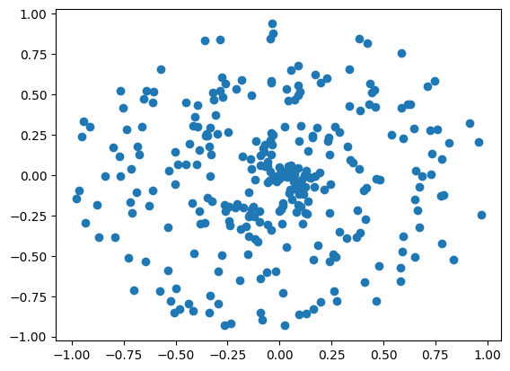

```python
from nnfs.datasets import spiral_data
import numpy as np
import nnfs
nnfs.init()
import matplotlib.pyplot as plt
X, y = spiral_data(samples=100, classes=3)
plt.scatter(X[:, 0], X[:, 1])
plt.show()
```

Разликата между двата начина на визуализация:

Първата визуализация (само точките): python

plt.scatter(X[:, 0], X[:, 1])

```
Всички точки са в един цвят (син)

Не можете да различите кой клас е коя точка
```

Втората визуализация (с цветове по клас): python

plt.scatter(X[:, 0], X[:, 1], c=y, cmap='brg')

```
c=y - оцветява точките според техния клас (y съдържа етикетите 0, 1 или 2)

cmap='brg' - използва цветова схема: Blue (син), Red (червен), Green (зелен)

Сега ясно се виждат 3-те различни спирали (класа)
```

Пример: Ако имаме точка X[0] = [0.5, 0.8]:

```
X[0, 0] = 0.5 → това е х координатата

X[0, 1] = 0.8 → това е y координатата

Точката се поставя на позиция (0.5, 0.8) в точковата диаграма
```

Така че да, x1 и x2 (както ги наричате) се засичат, за да формират всяка точка в двумерното пространство!

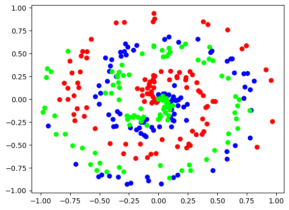

```python
plt.scatter(X[:, 0], X[:, 1], c=y, cmap='brg')
plt.show()
```

The neural network will not be aware of the color differences as the data have no class encodings

**DENSE LAYER CLASS**

Защо използваме новата конвенция?

В класическия запис на невронни мрежи входовете се представят като колонен вектор с размер n × 1, а теглата — като матрица W с размер m × n (неврони × входове). Изходът се пресмята по формулата: z = W · x + b

Когато обаче работим с множество проби (примери) едновременно (batch processing), подреждаме входовете като матрица X с размер (брой_проби × n). При класическата конвенция това налага транспониране на теглата, защото размерностите иначе не съвпадат: Z = X · Wᵀ + b

Постоянното писане на .T или np.transpose() в кода: затруднява четенето, добавя излишна изчислителна стъпка при всяко forward passthrough, замърсява кода с детайли, които нямат отношение към логиката на мрежата.

Новата конвенция (използвана в съвременните библиотеки)

Вместо да транспонираме при всяко умножение, дефинираме теглата директно в обратния ред — матрицата W вече има размер (входове × неврони). Тогава формулата опростява до: Z = X · W + b където:

X е с размер (проби × входове)

W е с размер (входове × неврони)

Z е с размер (проби × неврони)

Предимства на новата конвенция

✅ По-чист запис — формулата Z = X · W + b е интуитивна и се чете директно

✅ По-малко операции — спестява се транспонирането при всяко forward pass, което е важно при големи мрежи, тренирани хиляди пъти

✅ По-удобно за NumPy — работи се директно с матриците, без междинни трансформации

✅ Стандарт в deep learning библиотеките — точно по този начин работят PyTorch, TensorFlow/Keras, JAX и др.

[figure not shown]

Преимер със спираловидни данни (spiral data)

[figure not shown]

```python
import numpy as np
import nnfs
from nnfs.datasets import spiral_data
nnfs.init()
# Dense layer
class Layer_Dense:
 # Layer initialization
 def __init__(self, n_inputs, n_neurons):
 # Initialize weights and biases
   self.weights = 0.01 * np.random.randn(n_inputs, n_neurons)
   self.biases = np.zeros((1, n_neurons))

 # Forward pass
 def forward(self, inputs):
 # Calculate output values from inputs, weights and biases
   self.output = np.dot(inputs, self.weights) + self.biases

# Create dataset
X, y = spiral_data(samples=100, classes=3)
# Create Dense layer with 2 input features and 3 output values
dense1 = Layer_Dense(2, 3)
# Perform a forward pass of our training data through this layer
dense1.forward(X)


# Let's see output of the first few samples:
print(dense1.output[:5])
```

```
[[ 0.0000000e+00  0.0000000e+00  0.0000000e+00]
 [-1.0475188e-04  1.1395361e-04 -4.7983500e-05]
 [-2.7414842e-04  3.1729150e-04 -8.6921798e-05]
 [-4.2188365e-04  5.2666257e-04 -5.5912682e-05]
 [-5.7707680e-04  7.1401405e-04 -8.9430439e-05]]
```

**ACTIVATION FUNCTION: RELU**

```python
import numpy as np
inputs = [0, 2, -1, 3.3, -2.7, 1.1, 2.2, -100]
output = np.maximum(0, inputs)
print(output)
```

```
[0.  2.  0.  3.3 0.  1.1 2.2 0. ]
```

```python
# ReLU activation
class Activation_ReLU:
 # Forward pass
 def forward(self, inputs):
 # Calculate output values from input
  self.output = np.maximum(0, inputs)
```

```python
# Create dataset
X, y = spiral_data(samples=100, classes=3)
# Create Dense layer with 2 input features and 3 output values
dense1 = Layer_Dense(2, 3)
# Create ReLU activation (to be used with Dense layer):
activation1 = Activation_ReLU()
# Make a forward pass of our training data through this layer
dense1.forward(X)
# Forward pass through activation func.
# Takes in output from previous layer
activation1.forward(dense1.output)
# Let's see output of the first few samples:
print(activation1.output[:5])
```

```
[[0. 0. 0.]
 [0. 0. 0.]
 [0. 0. 0.]
 [0. 0. 0.]
 [0. 0. 0.]]
```

**ACTIVATION FUNCTION: SOFTMAX**

```python
### TRY THESE EXERCISES FOR YOURSELF!

A = [[1, 2, 3], [4, 5, 6], [7, 8,9]]
print(np.sum(A))

print(np.sum(A, axis = 0))
print(np.sum(A, axis = 0).shape)

print(np.sum(A, axis = 1))
print(np.sum(A, axis = 1).shape)

print(np.sum(A, axis = 0,keepdims = True))
print(np.sum(A, axis = 0,keepdims = True).shape)

print(np.sum(A, axis = 1,keepdims = True))
print(np.sum(A, axis = 1,keepdims = True).shape)

print(np.max(A, axis = 0))
print(np.max(A, axis = 1))
```

```
45
[12 15 18]
(3,)
[ 6 15 24]
(3,)
[[12 15 18]]
(1, 3)
[[ 6]
 [15]
 [24]]
(3, 1)
[7 8 9]
[3 6 9]
```

```python
inputs = [[1, 2, 3, 2.5],
 [2., 5., -1., 2],
 [-1.5, 2.7, 3.3, -0.8]]

# Get unnormalized probabilities
exp_values = np.exp(inputs - np.max(inputs, axis=1,keepdims=True))
 # Normalize them for each sample
probabilities = exp_values / np.sum(exp_values, axis=1,keepdims=True)
print(probabilities)
np.sum(probabilities, axis = 1)
```

```
[[0.06414769 0.17437149 0.47399085 0.28748998]
 [0.04517666 0.90739747 0.00224921 0.04517666]
 [0.00522984 0.34875873 0.63547983 0.0105316 ]]
```

```
array([1., 1., 1.])
```

```python
# Softmax activation
class Activation_Softmax:
 # Forward pass
 def forward(self, inputs):
 # Get unnormalized probabilities
  exp_values = np.exp(inputs - np.max(inputs, axis=1, keepdims=True))
 # Normalize them for each sample
  probabilities = exp_values / np.sum(exp_values, axis=1,keepdims=True)
  self.output = probabilities
```

**ONE FORWARD PASS (WITHOUT LOSS)**

```python
# Create dataset
X, y = spiral_data(samples=100, classes=3)
# Create Dense layer with 2 input features and 3 output values
dense1 = Layer_Dense(2, 3)
# Create ReLU activation (to be used with Dense layer):
activation1 = Activation_ReLU()
# Create second Dense layer with 3 input features (as we take output
# of previous layer here) and 3 output values
dense2 = Layer_Dense(3, 3)
# Create Softmax activation (to be used with Dense layer):
activation2 = Activation_Softmax()

# Make a forward pass of our training data through this layer
dense1.forward(X)

# Make a forward pass through activation function
# it takes the output of first dense layer here
activation1.forward(dense1.output)
# Make a forward pass through second Dense layer
# it takes outputs of activation function of first layer as inputs
dense2.forward(activation1.output)
# Make a forward pass through activation function
# it takes the output of second dense layer here
activation2.forward(dense2.output)
# Let's see output of the first few samples:
print(activation2.output[:5])
```

```
[[0.33333334 0.33333334 0.33333334]
 [0.33333364 0.3333334  0.3333329 ]
 [0.33333385 0.3333335  0.33333266]
 [0.33333433 0.3333336  0.33333206]
 [0.33333462 0.33333373 0.33333164]]
```

**CALCULATING NETWORK ERROR WITH LOSS**

CROSS ENTROPY LOSS BUILDING BLOCKS IN PYTHON

```python
softmax_outputs = np.array([[0.7, 0.1, 0.2],
 [0.1, 0.5, 0.4],
 [0.02, 0.9, 0.08]])
class_targets = [0, 1, 1]
print(softmax_outputs[range(len(softmax_outputs)), class_targets])
```

```
[0.7 0.5 0.9]
```

```python
range(len(softmax_outputs))
```

```
range(0, 3)
```

```python
print(-np.log(softmax_outputs[
 range(len(softmax_outputs)), class_targets
]))
neg_log = -np.log(softmax_outputs[
 range(len(softmax_outputs)), class_targets
 ])
average_loss = np.mean(neg_log)
print(average_loss)
```

```
[0.35667494 0.69314718 0.10536052]
0.38506088005216804
```

IF DATA IS ONE HOT ENCODED, HOW TO EXTRACT THE RELEVANT PREDICTIONS

```python
y_true_check = np.array([
    [1, 0, 0],
    [0, 1, 0],
    [0, 1, 0]
])

y_pred_clipped_check = np.array([
    [0.7, 0.2, 0.1],
    [0.1, 0.5, 0.4],
    [0.02, 0.9, 0.08]
])

A = y_true_check*y_pred_clipped_check
B = np.sum(A, axis = 1)
C = - np.log(B)

print(C)
print(np.mean(C))
```

```
[0.35667494 0.69314718 0.10536052]
0.38506088005216804
```

IMPLEMENTING THE LOSS CLASS

```python
# Common loss class
class Loss:
 # Calculates the data and regularization losses
 # given model output and ground truth values
 def calculate(self, output, y):
  # Calculate sample losses
  sample_losses = self.forward(output, y)
  # Calculate mean loss
  data_loss = np.mean(sample_losses)
  # Return loss
  return data_loss
```

IMPLEMENTING THE CATEGORICAL CROSS ENTROPY CLASS

```python
# Cross-entropy loss
class Loss_CategoricalCrossentropy(Loss):
 # Forward pass
 def forward(self, y_pred, y_true):
  # Number of samples in a batch
  samples = len(y_pred)
  # Clip data to prevent division by 0
  # Clip both sides to not drag mean towards any value
  y_pred_clipped = np.clip(y_pred, 1e-7, 1 - 1e-7)
  # Probabilities for target values -
  # only if categorical labels
  if len(y_true.shape) == 1:
   correct_confidences = y_pred_clipped[
   range(samples),
   y_true
   ]
  # Mask values - only for one-hot encoded labels
  elif len(y_true.shape) == 2:
   correct_confidences = np.sum(
   y_pred_clipped*y_true,
   axis=1
   )
 # Losses
  negative_log_likelihoods = -np.log(correct_confidences)
  return negative_log_likelihoods
```

```python
softmax_outputs = np.array([[0.7, 0.1, 0.2],
 [0.1, 0.5, 0.4],
 [0.02, 0.9, 0.08]])
class_targets = np.array([[1, 0, 0],
 [0, 1, 0],
 [0, 1, 0]])
loss_function = Loss_CategoricalCrossentropy()
loss = loss_function.calculate(softmax_outputs, class_targets)
print(loss)
```

```
0.38506088005216804
```

FULL CODE UPTO THIS POINT

```python
# Create dataset
X, y = spiral_data(samples=100, classes=3)
# Create Dense layer with 2 input features and 3 output values
dense1 = Layer_Dense(2, 3)
# Create ReLU activation (to be used with Dense layer):
activation1 = Activation_ReLU()
# Create second Dense layer with 3 input features (as we take output
# of previous layer here) and 3 output values
dense2 = Layer_Dense(3, 3)
# Create Softmax activation (to be used with Dense layer):
activation2 = Activation_Softmax()
# Create loss function
loss_function = Loss_CategoricalCrossentropy()


# Perform a forward pass of our training data through this layer
dense1.forward(X)
# Perform a forward pass through activation function
# it takes the output of first dense layer here
activation1.forward(dense1.output)

# Perform a forward pass through second Dense layer
# it takes outputs of activation function of first layer as inputs
dense2.forward(activation1.output)
# Perform a forward pass through activation function
# it takes the output of second dense layer here
activation2.forward(dense2.output)
# Let's see output of the first few samples:
print(activation2.output[:5])
# Perform a forward pass through activation function
# it takes the output of second dense layer here and returns loss
loss = loss_function.calculate(activation2.output, y)
# Print loss value
print('loss:', loss)

# Calculate accuracy from output of activation2 and targets
# calculate values along first axis
predictions = np.argmax(activation2.output, axis=1)
if len(y.shape) == 2:
 y = np.argmax(y, axis=1)
accuracy = np.mean(predictions == y)
# Print accuracy
print('acc:', accuracy)
```

```
[[0.33333334 0.33333334 0.33333334]
 [0.3333341  0.33333302 0.3333329 ]
 [0.3333341  0.33333302 0.33333296]
 [0.3333341  0.333333   0.33333293]
 [0.3333364  0.33333203 0.33333158]]
loss: 1.0986193
acc: 0.28
```

**INTRODUCING ACCURACY**

```python
import numpy as np
# Probabilities of 3 samples
softmax_outputs = np.array([[0.7, 0.2, 0.1],
 [0.1, 0.5, 0.4],
 [0.02, 0.9, 0.08]])
# Target (ground-truth) labels for 3 samples
class_targets = np.array([0, 1, 1])
# Calculate values along second axis (axis of index 1)
predictions = np.argmax(softmax_outputs, axis=1)
# If targets are one-hot encoded - convert them
if len(class_targets.shape) == 2:
 class_targets = np.argmax(class_targets, axis=1)
# True evaluates to 1; False to 0
accuracy = np.mean(predictions == class_targets)
print('acc:', accuracy)
```

```
acc: 1.0
```

**THE NEED FOR OPTIMIZATION**

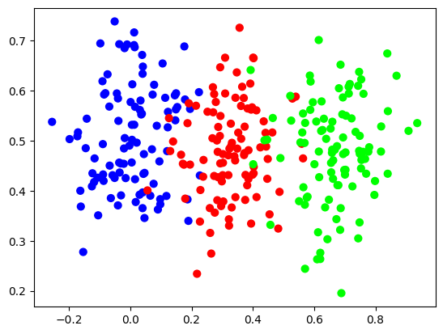

```python
#SIMPLER DATASET
import matplotlib.pyplot as plt
import nnfs
from nnfs.datasets import vertical_data
nnfs.init()
X, y = vertical_data(samples=100, classes=3)
plt.scatter(X[:, 0], X[:, 1], c=y, s=40, cmap='brg')
plt.show()
```

STRATEGY 1: RANDOMLY SELECT WEIGHTS AND BIASES - DOES NOT WORK!

```python
# Create dataset
X, y = vertical_data(samples=100, classes=3)
# Create model
dense1 = Layer_Dense(2, 3) # first dense layer, 2 inputs
activation1 = Activation_ReLU()
dense2 = Layer_Dense(3, 3) # second dense layer, 3 inputs, 3 outputs
activation2 = Activation_Softmax()
# Create loss function
loss_function = Loss_CategoricalCrossentropy()

# Helper variables
lowest_loss = 9999999 # some initial value
best_dense1_weights = dense1.weights.copy()
best_dense1_biases = dense1.biases.copy()
best_dense2_weights = dense2.weights.copy()
best_dense2_biases = dense2.biases.copy()

for iteration in range(100000):
 # Generate a new set of weights for iteration
 dense1.weights = 0.05 * np.random.randn(2, 3)
 dense1.biases = 0.05 * np.random.randn(1, 3)
 dense2.weights = 0.05 * np.random.randn(3, 3)
 dense2.biases = 0.05 * np.random.randn(1, 3)
 # Perform a forward pass of the training data through this layer
 dense1.forward(X)
 activation1.forward(dense1.output)
 dense2.forward(activation1.output)
 activation2.forward(dense2.output)
 # Perform a forward pass through activation function
 # it takes the output of second dense layer here and returns loss
 loss = loss_function.calculate(activation2.output, y)
 # Calculate accuracy from output of activation2 and targets
 # calculate values along first axis
 predictions = np.argmax(activation2.output, axis=1)
 accuracy = np.mean(predictions == y)
 # If loss is smaller - print and save weights and biases aside
 if loss < lowest_loss:
   print('New set of weights found, iteration:', iteration,'loss:', loss, 'acc:', accuracy)
   best_dense1_weights = dense1.weights.copy()
   best_dense1_biases = dense1.biases.copy()
   best_dense2_weights = dense2.weights.copy()
   best_dense2_biases = dense2.biases.copy()
   lowest_loss = loss
```

```
New set of weights found, iteration: 0 loss: 1.1016203 acc: 0.3333333333333333
New set of weights found, iteration: 1 loss: 1.1002508 acc: 0.3333333333333333
New set of weights found, iteration: 2 loss: 1.0992025 acc: 0.3333333333333333
New set of weights found, iteration: 3 loss: 1.0986239 acc: 0.3333333333333333
New set of weights found, iteration: 10 loss: 1.0984299 acc: 0.3333333333333333
New set of weights found, iteration: 22 loss: 1.0976521 acc: 0.36333333333333334
New set of weights found, iteration: 150 loss: 1.0974255 acc: 0.3333333333333333
New set of weights found, iteration: 874 loss: 1.0972673 acc: 0.3333333333333333
New set of weights found, iteration: 894 loss: 1.096895 acc: 0.3333333333333333
New set of weights found, iteration: 1036 loss: 1.095428 acc: 0.3333333333333333
New set of weights found, iteration: 88633 loss: 1.0952065 acc: 0.3333333333333333
```

STRATEGY 2: RANDOMLY ADJUST WEIGHTS AND BIASES - WORKS!

```python
# Create dataset
X, y = vertical_data(samples=100, classes=3)
# Create model
dense1 = Layer_Dense(2, 3) # first dense layer, 2 inputs
activation1 = Activation_ReLU()
dense2 = Layer_Dense(3, 3) # second dense layer, 3 inputs, 3 outputs
activation2 = Activation_Softmax()
# Create loss function
loss_function = Loss_CategoricalCrossentropy()
# Helper variables
lowest_loss = 9999999 # some initial value
best_dense1_weights = dense1.weights.copy()
best_dense1_biases = dense1.biases.copy()
best_dense2_weights = dense2.weights.copy()
best_dense2_biases = dense2.biases.copy()
for iteration in range(10000):
 # Update weights with some small random values
 dense1.weights += 0.05 * np.random.randn(2, 3)
 dense1.biases += 0.05 * np.random.randn(1, 3)
 dense2.weights += 0.05 * np.random.randn(3, 3)
 dense2.biases += 0.05 * np.random.randn(1, 3)
 # Perform a forward pass of our training data through this layer
 dense1.forward(X)
 activation1.forward(dense1.output)
 dense2.forward(activation1.output)
 activation2.forward(dense2.output)
 # Perform a forward pass through activation function
 # it takes the output of second dense layer here and returns loss
 loss = loss_function.calculate(activation2.output, y)
 # Calculate accuracy from output of activation2 and targets
 # calculate values along first axis
 predictions = np.argmax(activation2.output, axis=1)
 accuracy = np.mean(predictions == y)
 # If loss is smaller - print and save weights and biases aside
 if loss < lowest_loss:
  print('New set of weights found, iteration:', iteration,'loss:', loss, 'acc:', accuracy)
  best_dense1_weights = dense1.weights.copy()
  best_dense1_biases = dense1.biases.copy()
  best_dense2_weights = dense2.weights.copy()
  best_dense2_biases = dense2.biases.copy()
  lowest_loss = loss
 # Revert weights and biases
 else:
  dense1.weights = best_dense1_weights.copy()
  dense1.biases = best_dense1_biases.copy()
  dense2.weights = best_dense2_weights.copy()
  dense2.biases = best_dense2_biases.copy()
```

```
New set of weights found, iteration: 0 loss: 1.1008747 acc: 0.3333333333333333
New set of weights found, iteration: 3 loss: 1.1005714 acc: 0.3333333333333333
New set of weights found, iteration: 4 loss: 1.099462 acc: 0.3333333333333333
New set of weights found, iteration: 9 loss: 1.0994359 acc: 0.3333333333333333
New set of weights found, iteration: 10 loss: 1.09855 acc: 0.3333333333333333
New set of weights found, iteration: 13 loss: 1.098517 acc: 0.3333333333333333
New set of weights found, iteration: 14 loss: 1.0938607 acc: 0.3333333333333333
New set of weights found, iteration: 15 loss: 1.0920315 acc: 0.3333333333333333
New set of weights found, iteration: 17 loss: 1.091391 acc: 0.3333333333333333
New set of weights found, iteration: 19 loss: 1.0910357 acc: 0.3333333333333333
New set of weights found, iteration: 20 loss: 1.0898421 acc: 0.3333333333333333
New set of weights found, iteration: 21 loss: 1.0843327 acc: 0.3333333333333333
New set of weights found, iteration: 26 loss: 1.0835577 acc: 0.3333333333333333
New set of weights found, iteration: 27 loss: 1.0823517 acc: 0.3333333333333333
New set of weights found, iteration: 28 loss: 1.0778279 acc: 0.3333333333333333
New set of weights found, iteration: 31 loss: 1.076321 acc: 0.3333333333333333
New set of weights found, iteration: 35 loss: 1.0729524 acc: 0.3
New set of weights found, iteration: 36 loss: 1.0699975 acc: 0.3333333333333333
New set of weights found, iteration: 47 loss: 1.0631136 acc: 0.3333333333333333
New set of weights found, iteration: 52 loss: 1.062574 acc: 0.3333333333333333
New set of weights found, iteration: 53 loss: 1.0624933 acc: 0.3333333333333333
New set of weights found, iteration: 54 loss: 1.0592291 acc: 0.3333333333333333
New set of weights found, iteration: 57 loss: 1.0574998 acc: 0.3333333333333333
New set of weights found, iteration: 58 loss: 1.0493913 acc: 0.38
New set of weights found, iteration: 64 loss: 1.0450443 acc: 0.65
New set of weights found, iteration: 68 loss: 1.0377563 acc: 0.65
New set of weights found, iteration: 70 loss: 1.0333902 acc: 0.66
New set of weights found, iteration: 71 loss: 1.0315365 acc: 0.63
New set of weights found, iteration: 74 loss: 1.0283976 acc: 0.6033333333333334
New set of weights found, iteration: 75 loss: 1.0214951 acc: 0.6133333333333333
New set of weights found, iteration: 82 loss: 1.0101981 acc: 0.6466666666666666
New set of weights found, iteration: 84 loss: 1.0100108 acc: 0.5733333333333334
New set of weights found, iteration: 90 loss: 1.0035288 acc: 0.7133333333333334
New set of weights found, iteration: 92 loss: 1.0008268 acc: 0.65
New set of weights found, iteration: 95 loss: 0.99175525 acc: 0.6
New set of weights found, iteration: 98 loss: 0.9812336 acc: 0.66
New set of weights found, iteration: 101 loss: 0.97777444 acc: 0.58
New set of weights found, iteration: 106 loss: 0.977026 acc: 0.67
New set of weights found, iteration: 110 loss: 0.97546613 acc: 0.6766666666666666
New set of weights found, iteration: 111 loss: 0.9656759 acc: 0.9066666666666666
```

[output cut: 235 more lines]

```
New set of weights found, iteration: 2874 loss: 0.17114341 acc: 0.93
New set of weights found, iteration: 2978 loss: 0.17100853 acc: 0.93
New set of weights found, iteration: 3138 loss: 0.17093514 acc: 0.9266666666666666
New set of weights found, iteration: 3293 loss: 0.17080545 acc: 0.9266666666666666
New set of weights found, iteration: 3486 loss: 0.1707664 acc: 0.93
New set of weights found, iteration: 3681 loss: 0.17070974 acc: 0.93
New set of weights found, iteration: 4038 loss: 0.17066137 acc: 0.93
New set of weights found, iteration: 4090 loss: 0.17065905 acc: 0.93
New set of weights found, iteration: 4116 loss: 0.17063397 acc: 0.93
New set of weights found, iteration: 4258 loss: 0.17062972 acc: 0.93
New set of weights found, iteration: 5960 loss: 0.17062148 acc: 0.93
New set of weights found, iteration: 6352 loss: 0.17058212 acc: 0.93
New set of weights found, iteration: 8192 loss: 0.17057395 acc: 0.93
New set of weights found, iteration: 8254 loss: 0.17056267 acc: 0.93
New set of weights found, iteration: 9463 loss: 0.17056097 acc: 0.93
```

STRATEGY 2: FOR SPIRAL DATASET - DOES NOT WORK!

```python
# Create dataset
X, y = spiral_data(samples=100, classes=3)# Create model
dense1 = Layer_Dense(2, 3) # first dense layer, 2 inputs
activation1 = Activation_ReLU()
dense2 = Layer_Dense(3, 3) # second dense layer, 3 inputs, 3 outputs
activation2 = Activation_Softmax()
# Create loss function
loss_function = Loss_CategoricalCrossentropy()
# Helper variables
lowest_loss = 9999999 # some initial value
best_dense1_weights = dense1.weights.copy()
best_dense1_biases = dense1.biases.copy()
best_dense2_weights = dense2.weights.copy()
best_dense2_biases = dense2.biases.copy()
for iteration in range(10000):
 # Update weights with some small random values
 dense1.weights += 0.05 * np.random.randn(2, 3)
 dense1.biases += 0.05 * np.random.randn(1, 3)
 dense2.weights += 0.05 * np.random.randn(3, 3)
 dense2.biases += 0.05 * np.random.randn(1, 3)
 # Perform a forward pass of our training data through this layer
 dense1.forward(X)
 activation1.forward(dense1.output)
 dense2.forward(activation1.output)
 activation2.forward(dense2.output)
 # Perform a forward pass through activation function
 # it takes the output of second dense layer here and returns loss
 loss = loss_function.calculate(activation2.output, y)
 # Calculate accuracy from output of activation2 and targets
 # calculate values along first axis
 predictions = np.argmax(activation2.output, axis=1)
 accuracy = np.mean(predictions == y)
 # If loss is smaller - print and save weights and biases aside
 if loss < lowest_loss:
  print('New set of weights found, iteration:', iteration,'loss:', loss, 'acc:', accuracy)
  best_dense1_weights = dense1.weights.copy()
  best_dense1_biases = dense1.biases.copy()
  best_dense2_weights = dense2.weights.copy()
  best_dense2_biases = dense2.biases.copy()
  lowest_loss = loss
 # Revert weights and biases
 else:
  dense1.weights = best_dense1_weights.copy()
  dense1.biases = best_dense1_biases.copy()
  dense2.weights = best_dense2_weights.copy()
  dense2.biases = best_dense2_biases.copy()
```

```
New set of weights found, iteration: 0 loss: 1.0991902 acc: 0.3333333333333333
New set of weights found, iteration: 1 loss: 1.0988214 acc: 0.3333333333333333
New set of weights found, iteration: 6 loss: 1.0982754 acc: 0.3333333333333333
New set of weights found, iteration: 14 loss: 1.0978643 acc: 0.3333333333333333
New set of weights found, iteration: 23 loss: 1.0972557 acc: 0.35
New set of weights found, iteration: 37 loss: 1.0970367 acc: 0.35
New set of weights found, iteration: 40 loss: 1.0958394 acc: 0.37
New set of weights found, iteration: 41 loss: 1.0950066 acc: 0.4066666666666667
New set of weights found, iteration: 44 loss: 1.0948946 acc: 0.37333333333333335
New set of weights found, iteration: 53 loss: 1.0943341 acc: 0.3933333333333333
New set of weights found, iteration: 58 loss: 1.0942849 acc: 0.36666666666666664
New set of weights found, iteration: 59 loss: 1.0941792 acc: 0.35
New set of weights found, iteration: 60 loss: 1.0926698 acc: 0.38666666666666666
New set of weights found, iteration: 61 loss: 1.0913428 acc: 0.3933333333333333
New set of weights found, iteration: 63 loss: 1.0910325 acc: 0.4066666666666667
New set of weights found, iteration: 65 loss: 1.0902771 acc: 0.3933333333333333
New set of weights found, iteration: 75 loss: 1.0892566 acc: 0.39
New set of weights found, iteration: 88 loss: 1.0892477 acc: 0.39666666666666667
New set of weights found, iteration: 90 loss: 1.0862132 acc: 0.39
New set of weights found, iteration: 95 loss: 1.0858525 acc: 0.38333333333333336
New set of weights found, iteration: 99 loss: 1.0850619 acc: 0.44
New set of weights found, iteration: 103 loss: 1.0833515 acc: 0.4166666666666667
New set of weights found, iteration: 108 loss: 1.0818787 acc: 0.41333333333333333
New set of weights found, iteration: 111 loss: 1.0813941 acc: 0.39
New set of weights found, iteration: 113 loss: 1.0787892 acc: 0.38666666666666666
New set of weights found, iteration: 114 loss: 1.0777413 acc: 0.36333333333333334
New set of weights found, iteration: 116 loss: 1.0772293 acc: 0.38
New set of weights found, iteration: 121 loss: 1.0759072 acc: 0.3933333333333333
New set of weights found, iteration: 132 loss: 1.075869 acc: 0.43
New set of weights found, iteration: 134 loss: 1.075571 acc: 0.39666666666666667
New set of weights found, iteration: 143 loss: 1.0749155 acc: 0.4066666666666667
New set of weights found, iteration: 148 loss: 1.0747138 acc: 0.4066666666666667
New set of weights found, iteration: 156 loss: 1.0740647 acc: 0.42
New set of weights found, iteration: 183 loss: 1.0736305 acc: 0.42333333333333334
New set of weights found, iteration: 184 loss: 1.0735968 acc: 0.4266666666666667
New set of weights found, iteration: 196 loss: 1.0734725 acc: 0.4266666666666667
New set of weights found, iteration: 197 loss: 1.0726037 acc: 0.44
New set of weights found, iteration: 198 loss: 1.0724471 acc: 0.4533333333333333
New set of weights found, iteration: 213 loss: 1.0718489 acc: 0.38666666666666666
New set of weights found, iteration: 225 loss: 1.07182 acc: 0.4166666666666667
New set of weights found, iteration: 228 loss: 1.0711939 acc: 0.41
New set of weights found, iteration: 276 loss: 1.0709915 acc: 0.42
New set of weights found, iteration: 395 loss: 1.0707066 acc: 0.42333333333333334
New set of weights found, iteration: 471 loss: 1.070367 acc: 0.42
New set of weights found, iteration: 1317 loss: 1.0702449 acc: 0.43333333333333335
New set of weights found, iteration: 1857 loss: 1.0702258 acc: 0.43333333333333335
New set of weights found, iteration: 2198 loss: 1.070218 acc: 0.4266666666666667
New set of weights found, iteration: 2315 loss: 1.0701423 acc: 0.44333333333333336
New set of weights found, iteration: 5115 loss: 1.0700669 acc: 0.43333333333333335
New set of weights found, iteration: 5942 loss: 1.069947 acc: 0.44333333333333336
```

**BACKPROPAGATION**

GRADIENTS OF THE LOSS WITH RESPECT TO WEIGHTS

[figure not shown]

```python
import numpy as np
# Passed-in gradient from the next layer
# for the purpose of this example we're going to use
# an array of an incremental gradient values
dvalues = np.array([[1., 1., 1.],
 [2., 2., 2.],
 [3., 3., 3.]])
# We have 3 sets of inputs - samples
inputs = np.array([[1, 2, 3, 2.5],
 [2., 5., -1., 2],
 [-1.5, 2.7, 3.3, -0.8]])
# sum weights of given input
# and multiply by the passed-in gradient for this neuron
dweights = np.dot(inputs.T, dvalues)
print(dweights)
```

```
[[ 0.5  0.5  0.5]
 [20.1 20.1 20.1]
 [10.9 10.9 10.9]
 [ 4.1  4.1  4.1]]
```

GRADIENTS OF THE LOSS WITH RESPECT TO BIASES

[figure not shown]

```python
import numpy as np
# Passed-in gradient from the next layer
# for the purpose of this example we're going to use
# an array of an incremental gradient values
dvalues = np.array([[1., 1., 1.],
 [2., 2., 2.],
 [3., 3., 3.]])
# One bias for each neuron
# biases are the row vector with a shape (1, neurons)
biases = np.array([[2, 3, 0.5]])
# dbiases - sum values, do this over samples (first axis), keepdims
# since this by default will produce a plain list -
# we explained this in the chapter 4
dbiases = np.sum(dvalues, axis=0, keepdims=True)
print(dbiases)
```

```
[[6. 6. 6.]]
```

GRADIENTS OF THE LOSS WITH RESPECT TO INPUTS

[figure not shown]

```python
import numpy as np
# Passed-in gradient from the next layer
# for the purpose of this example we're going to use
# an array of an incremental gradient values
dvalues = np.array([[1., 1., 1.],
 [2., 2., 2.],
 [3., 3., 3.]])
# We have 3 sets of weights - one set for each neuron
# we have 4 inputs, thus 4 weights
# recall that we keep weights transposed
weights = np.array([[0.2, 0.8, -0.5, 1],
 [0.5, -0.91, 0.26, -0.5],
 [-0.26, -0.27, 0.17, 0.87]]).T
# sum weights of given input
# and multiply by the passed-in gradient for this neuron
dinputs = np.dot(dvalues, weights.T)
print(dinputs)
```

```
[[ 0.44 -0.38 -0.07  1.37]
 [ 0.88 -0.76 -0.14  2.74]
 [ 1.32 -1.14 -0.21  4.11]]
```

ADDING THE "BACKWARD" METHOD IN THE LAYER-DENSE CLASS

```python
# class Layer_Dense:
#  ...
#  # Backward pass
#  def backward(self, dvalues):
#  # Gradients on parameters
#  self.dweights = np.dot(self.inputs.T, dvalues)
#  self.dbiases = np.sum(dvalues, axis=0, keepdims=True)
#  # Gradient on values
#  self.dinputs = np.dot(dvalues, self.weights.T)
```

ADDING THE "BACKWARD" METHOD IN THE RELU ACTIVATION CLASS

```python
# # ReLU activation
# class Activation_ReLU:
#  # Forward pass
#  def forward(self, inputs):
#  # Remember input values
#  self.inputs = inputs
#  self.output = np.maximum(0, inputs)
#  # Backward pass
#  def backward(self, dvalues):
#  # Since we need to modify the original variable,
#  # let's make a copy of the values first
#  self.dinputs = dvalues.copy()
#  # Zero gradient where input values were negative
#  self.dinputs[self.inputs <= 0] = 0
```

LOSS FUNCTION BACKPROPAGATION

```python
# Common loss class
class Loss:
 # Calculates the data and regularization losses
 # given model output and ground truth values
 def calculate(self, output, y):
  # Calculate sample losses
  sample_losses = self.forward(output, y)
  # Calculate mean loss
  data_loss = np.mean(sample_losses)
  # Return loss
  return data_loss
```

```python
class Loss_CategoricalCrossentropy(Loss):
    # Forward pass
    def forward(self, y_pred, y_true):
        # Number of samples in a batch
        samples = len(y_pred)

        # Clip data to prevent division by 0
        # Clip both sides to not drag mean towards any value
        y_pred_clipped = np.clip(y_pred, 1e-7, 1 - 1e-7)

        # Probabilities for target values -
        # only if categorical labels
        if len(y_true.shape) == 1:
            correct_confidences = y_pred_clipped[
                range(samples),
                y_true
            ]
        # Mask values - only for one-hot encoded labels
        elif len(y_true.shape) == 2:
            correct_confidences = np.sum(
                y_pred_clipped * y_true,
                axis=1
            )

        # Losses
        negative_log_likelihoods = -np.log(correct_confidences)
        return negative_log_likelihoods

    # Backward pass
    def backward(self, dvalues, y_true):
        # Number of samples
        samples = len(dvalues)
        # Number of labels in every sample
        # We'll use the first sample to count them
        labels = len(dvalues[0])

        # If labels are sparse, turn them into one-hot vector
        if len(y_true.shape) == 1:
            y_true = np.eye(labels)[y_true]

        # Calculate gradient
        self.dinputs = -y_true / dvalues
        # Normalize gradient
        self.dinputs = self.dinputs / samples
```

Softmax classifier - combined Softmax activation and cross-entropy loss for faster backward step

```python
# Softmax classifier - combined Softmax activation
# and cross-entropy loss for faster backward step
class Activation_Softmax_Loss_CategoricalCrossentropy:
    # Creates activation and loss function objects
    def __init__(self):
        self.activation = Activation_Softmax()
        self.loss = Loss_CategoricalCrossentropy()

    # Forward pass
    def forward(self, inputs, y_true):
        # Output layer's activation function
        self.activation.forward(inputs)
        # Set the output
        self.output = self.activation.output
        # Calculate and return loss value
        return self.loss.calculate(self.output, y_true)

    # Backward pass
    def backward(self, dvalues, y_true):
        # Number of samples
        samples = len(dvalues)
        # If labels are one-hot encoded,
        # turn them into discrete values
        if len(y_true.shape) == 2:
            y_true = np.argmax(y_true, axis=1)
        # Copy so we can safely modify
        self.dinputs = dvalues.copy()
        # Calculate gradient
        self.dinputs[range(samples), y_true] -= 1
        # Normalize gradient
        self.dinputs = self.dinputs / samples
```

```python
softmax_outputs = np.array([[0.7, 0.1, 0.2],
 [0.1, 0.5, 0.4],
 [0.02, 0.9, 0.08]])
class_targets = np.array([0, 1, 1])
softmax_loss = Activation_Softmax_Loss_CategoricalCrossentropy()
softmax_loss.backward(softmax_outputs, class_targets)
dvalues1 = softmax_loss.dinputs
print('Gradients: combined loss and activation:')
print(dvalues1)
```

```
Gradients: combined loss and activation:
[[-0.1         0.03333333  0.06666667]
 [ 0.03333333 -0.16666667  0.13333333]
 [ 0.00666667 -0.03333333  0.02666667]]
```

**ALL CLASSES TOGETHER**

CREATING LAYERS: FORWARD AND BACKWARD PASS

```python
# Dense layer
class Layer_Dense:
    # Layer initialization
    def __init__(self, n_inputs, n_neurons):
        # Initialize weights and biases
        self.weights = 0.01 * np.random.randn(n_inputs, n_neurons)
        self.biases = np.zeros((1, n_neurons))

    # Forward pass
    def forward(self, inputs):
        # Remember input values
        self.inputs = inputs
        # Calculate output values from input ones, weights and biases
        self.output = np.dot(inputs, self.weights) + self.biases

    # Backward pass
    def backward(self, dvalues):
        # Gradients on parameters
        self.dweights = np.dot(self.inputs.T, dvalues)
        self.dbiases = np.sum(dvalues, axis=0, keepdims=True)
        # Gradient on values
        self.dinputs = np.dot(dvalues, self.weights.T)
```

RELU ACTIVATION: FORWARD AND BACKWARD PASS

```python
# ReLU activation
class Activation_ReLU:
    # Forward pass
    def forward(self, inputs):
        # Remember input values
        self.inputs = inputs
        # Calculate output values from inputs
        self.output = np.maximum(0, inputs)

    # Backward pass
    def backward(self, dvalues):
        # Since we need to modify the original variable,
        # let’s make a copy of values first
        self.dinputs = dvalues.copy()
        # Zero gradient where input values were negative
        self.dinputs[self.inputs <= 0] = 0
```

SOFTMAX ACTIVATION: FORWARD PASS

```python
# Softmax activation
class Activation_Softmax:
 # Forward pass
 def forward(self, inputs):
 # Get unnormalized probabilities
  exp_values = np.exp(inputs - np.max(inputs, axis=1, keepdims=True))
 # Normalize them for each sample
  probabilities = exp_values / np.sum(exp_values, axis=1,keepdims=True)
  self.output = probabilities
```

LOSS CLASS

```python
# Common loss class
class Loss:
 # Calculates the data and regularization losses
 # given model output and ground truth values
 def calculate(self, output, y):
  # Calculate sample losses
  sample_losses = self.forward(output, y)
  # Calculate mean loss
  data_loss = np.mean(sample_losses)
  # Return loss
  return data_loss
```

CATEGORICAL CROSS ENTROPY LOSS: FORWARD AND BACKWARD PASS

```python
class Loss_CategoricalCrossentropy(Loss):
    # Forward pass
    def forward(self, y_pred, y_true):
        # Number of samples in a batch
        samples = len(y_pred)

        # Clip data to prevent division by 0
        # Clip both sides to not drag mean towards any value
        y_pred_clipped = np.clip(y_pred, 1e-7, 1 - 1e-7)

        # Probabilities for target values -
        # only if categorical labels
        if len(y_true.shape) == 1:
            correct_confidences = y_pred_clipped[
                range(samples),
                y_true
            ]
        # Mask values - only for one-hot encoded labels
        elif len(y_true.shape) == 2:
            correct_confidences = np.sum(
                y_pred_clipped * y_true,
                axis=1
            )

        # Losses
        negative_log_likelihoods = -np.log(correct_confidences)
        return negative_log_likelihoods

    # Backward pass
    def backward(self, dvalues, y_true):
        # Number of samples
        samples = len(dvalues)
        # Number of labels in every sample
        # We'll use the first sample to count them
        labels = len(dvalues[0])

        # If labels are sparse, turn them into one-hot vector
        if len(y_true.shape) == 1:
            y_true = np.eye(labels)[y_true]

        # Calculate gradient
        self.dinputs = -y_true / dvalues
        # Normalize gradient
        self.dinputs = self.dinputs / samples
```

COMBINED SOFTMAX ACTIVATION AND CATEGORICAL CROSS ENTROPY FOR LAST LAYER: FORWARD AND BACKWARD PASS

```python
# Softmax classifier - combined Softmax activation
# and cross-entropy loss for faster backward step
class Activation_Softmax_Loss_CategoricalCrossentropy:
    # Creates activation and loss function objects
    def __init__(self):
        self.activation = Activation_Softmax()
        self.loss = Loss_CategoricalCrossentropy()

    # Forward pass
    def forward(self, inputs, y_true):
        # Output layer's activation function
        self.activation.forward(inputs)
        # Set the output
        self.output = self.activation.output
        # Calculate and return loss value
        return self.loss.calculate(self.output, y_true)

    # Backward pass
    def backward(self, dvalues, y_true):
        # Number of samples
        samples = len(dvalues)
        # If labels are one-hot encoded,
        # turn them into discrete values
        if len(y_true.shape) == 2:
            y_true = np.argmax(y_true, axis=1)
        # Copy so we can safely modify
        self.dinputs = dvalues.copy()
        # Calculate gradient
        self.dinputs[range(samples), y_true] -= 1
        # Normalize gradient
        self.dinputs = self.dinputs / samples
```

DATASET

```python
!pip install nnfs
```

```
Downloading nnfs-0.5.1-py3-none-any.whl (9.1 kB)
```

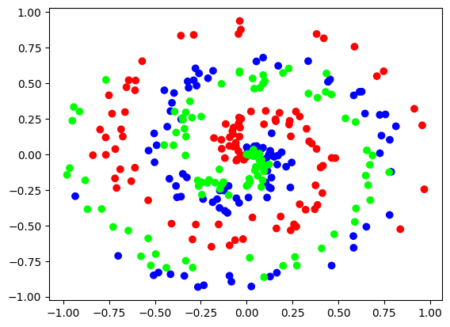

```python
from nnfs.datasets import spiral_data
import numpy as np
import nnfs
nnfs.init()
import matplotlib.pyplot as plt
X, y = spiral_data(samples=100, classes=3)
plt.scatter(X[:, 0], X[:, 1], c=y, cmap='brg')
plt.show()
```

**FULL CODE UPTO THIS POINT: FORWARD AND BACKWARD PASS**

```python
# Create dataset
X, y = spiral_data(samples=100, classes=3)
# Create Dense layer with 2 input features and 3 output values
dense1 = Layer_Dense(2, 3)
# Create ReLU activation (to be used with Dense layer):
activation1 = Activation_ReLU()
# Create second Dense layer with 3 input features (as we take output
# of previous layer here) and 3 output values (output values)
dense2 = Layer_Dense(3, 3)
# Create Softmax classifier’s combined loss and activation
loss_activation = Activation_Softmax_Loss_CategoricalCrossentropy()
# Perform a forward pass of our training data through this layer
dense1.forward(X)
# Perform a forward pass through activation function
# takes the output of first dense layer here
activation1.forward(dense1.output)
# Perform a forward pass through second Dense layer
# takes outputs of activation function of first layer as inputs
dense2.forward(activation1.output)
# Perform a forward pass through the activation/loss function
# takes the output of second dense layer here and returns loss
loss = loss_activation.forward(dense2.output, y)

# Let’s see output of the first few samples:
print(loss_activation.output[:5])
# Print loss value
print('loss:', loss)
# Calculate accuracy from output of activation2 and targets
# calculate values along first axis
predictions = np.argmax(loss_activation.output, axis=1)
if len(y.shape) == 2:
 y = np.argmax(y, axis=1)
accuracy = np.mean(predictions == y)
# Print accuracy
print('acc:', accuracy)
# Backward pass
loss_activation.backward(loss_activation.output, y)
dense2.backward(loss_activation.dinputs)
activation1.backward(dense2.dinputs)
dense1.backward(activation1.dinputs)
# Print gradients
print(dense1.dweights)
print(dense1.dbiases)
print(dense2.dweights)
print(dense2.dbiases)
```

```
[[0.33333334 0.33333334 0.33333334]
 [0.33333445 0.33333254 0.33333305]
 [0.3333352  0.33333153 0.33333325]
 [0.3333366  0.33333096 0.33333245]
 [0.333337   0.33332968 0.33333325]]
loss: 1.098619
acc: 0.35333333333333333
[[ 4.8014837e-05 -3.2882002e-04 -2.2865137e-05]
 [ 2.3710456e-04  1.3653119e-04  3.2834365e-04]]
[[0.00032909 0.00050736 0.00027409]]
[[ 1.12887094e-04 -6.63138344e-05 -4.65732774e-05]
 [ 2.32091443e-05  7.71948835e-05 -1.00404046e-04]
 [ 1.22063466e-04 -3.83295293e-04  2.61231849e-04]]
[[ 2.5826273e-05 -2.3534172e-05 -2.3175962e-06]]
```

Това е минимален, опростен пример за една единствена невронна мрежа с един неврон! Авторът го прескача, защото е само демонстрация – показва как работи градиентното спускане стъпка по стъпка т.е. как се изчисляват градиентите и как се актуализират теглата. Мрежа Един неврон (няма скрити слоеве) Вход 3 признака [1.0, -2.0, 3.0] Тегла [-3.0, -1.0, 2.0] Отклонение 1.0 Активация ReLU (проста, за демонстрация) Цел 0.0 (искаме моделът да предскаже 0) Загуба MSE (квадратична грешка) Оптимизатор GD (градиентно спускане) Епохи 200

```python
import numpy as np

# Initial parameters
weights = np.array([-3.0, -1.0, 2.0])
bias = 1.0
inputs = np.array([1.0, -2.0, 3.0])
target_output = 0.0
learning_rate = 0.001

def relu(x):
    return np.maximum(0, x)

def relu_derivative(x):
    return np.where(x > 0, 1.0, 0.0)

for iteration in range(200):
    # Forward pass
    linear_output = np.dot(weights, inputs) + bias
    output = relu(linear_output)
    loss = (output - target_output) ** 2

    # Backward pass
    dloss_doutput = 2 * (output - target_output)
    doutput_dlinear = relu_derivative(linear_output)
    dlinear_dweights = inputs
    dlinear_dbias = 1.0

    dloss_dlinear = dloss_doutput * doutput_dlinear
    dloss_dweights = dloss_dlinear * dlinear_dweights
    dloss_dbias = dloss_dlinear * dlinear_dbias

    # Update weights and bias
    weights -= learning_rate * dloss_dweights
    bias -= learning_rate * dloss_dbias

    # Print the loss for this iteration
    print(f"Iteration {iteration + 1}, Loss: {loss}")

print("Final weights:", weights)
print("Final bias:", bias)
```

```
Iteration 1, Loss: 36.0
Iteration 2, Loss: 33.872397424621624
Iteration 3, Loss: 31.87054345809546
Iteration 4, Loss: 29.98699091998773
Iteration 5, Loss: 28.214761511794592
Iteration 6, Loss: 26.54726775906168
Iteration 7, Loss: 24.978326552541866
Iteration 8, Loss: 23.5021050739742
Iteration 9, Loss: 22.11313179151597
Iteration 10, Loss: 20.806246424284897
Iteration 11, Loss: 19.576596334671486
Iteration 12, Loss: 18.41961908608719
Iteration 13, Loss: 17.33101994032309
Iteration 14, Loss: 16.306757070164853
Iteration 15, Loss: 15.343027506224132
Iteration 16, Loss: 14.436253786815284
Iteration 17, Loss: 13.583071280700132
Iteration 18, Loss: 12.780312744165439
Iteration 19, Loss: 12.024995767388878
Iteration 20, Loss: 11.314319082257104
Iteration 21, Loss: 10.64564263994962
Iteration 22, Loss: 10.016485041642266
Iteration 23, Loss: 9.424510031713222
Iteration 24, Loss: 8.867521365009814
Iteration 25, Loss: 8.34345204094211
Iteration 26, Loss: 7.850353118483743
Iteration 27, Loss: 7.386397874602818
Iteration 28, Loss: 6.94986173712617
Iteration 29, Loss: 6.539124434950737
Iteration 30, Loss: 6.1526621719118015
Iteration 31, Loss: 5.789039869058961
Iteration 32, Loss: 5.446907999417336
Iteration 33, Loss: 5.124995576577539
Iteration 34, Loss: 4.822108497170647
Iteration 35, Loss: 4.537121521071987
Iteration 36, Loss: 4.268978030723312
Iteration 37, Loss: 4.01668121563854
Iteration 38, Loss: 3.7792956126389763
Iteration 39, Loss: 3.5559389510643094
Iteration 40, Loss: 3.345782865003274
```

[output cut: 147 more lines]

```
Iteration 188, Loss: 0.000406378034681195
Iteration 189, Loss: 0.00038236074013664776
Iteration 190, Loss: 0.0003597649139507893
Iteration 191, Loss: 0.0003385032407062897
Iteration 192, Loss: 0.00031849748027454767
Iteration 193, Loss: 0.00029967346881992795
Iteration 194, Loss: 0.0002819629431575354
Iteration 195, Loss: 0.0002652991815966534
Iteration 196, Loss: 0.00024961903501571355
Iteration 197, Loss: 0.00023486641976601822
Iteration 198, Loss: 0.00022098629075865584
Iteration 199, Loss: 0.00020792651372860275
Iteration 200, Loss: 0.00019563773612380077
Final weights: [-3.3990955  -0.20180899  0.80271349]
Final bias: 0.6009044964517248
```

**OPTIMIZERS GRADIENT DESCENT**

```python
# SGD optimizer
class Optimizer_SGD:
 # Initialize optimizer - set settings,
 # learning rate of 1. is default for this optimizer
 def __init__(self, learning_rate=1):
  self.learning_rate = learning_rate
 # Update parameters
 def update_params(self, layer):
  layer.weights += -self.learning_rate * layer.dweights
  layer.biases += -self.learning_rate * layer.dbiases
```

```python
# Create dataset
X, y = spiral_data(samples=100, classes=3)

# Create Dense layer with 2 input features and 64 output values
dense1 = Layer_Dense(2, 64)

# Create ReLU activation (to be used with Dense layer)
activation1 = Activation_ReLU()

# Create second Dense layer with 64 input features (as we take output
# of previous layer here) and 3 output values (output values)
dense2 = Layer_Dense(64, 3)

# Create Softmax classifier's combined loss and activation
loss_activation = Activation_Softmax_Loss_CategoricalCrossentropy()

# Create optimizer
optimizer = Optimizer_SGD()

# Train in loop
for epoch in range(10001):
    # Perform a forward pass of our training data through this layer
    dense1.forward(X)

    # Perform a forward pass through activation function
    # takes the output of first dense layer here
    activation1.forward(dense1.output)

    # Perform a forward pass through second Dense layer
    # takes outputs of activation function of first layer as inputs
    dense2.forward(activation1.output)

    # Perform a forward pass through the activation/loss function
    # takes the output of second dense layer here and returns loss
    loss = loss_activation.forward(dense2.output, y)

    # Calculate accuracy from output of activation2 and targets
    # calculate values along first axis
    predictions = np.argmax(loss_activation.output, axis=1)
    if len(y.shape) == 2:
        y = np.argmax(y, axis=1)
    accuracy = np.mean(predictions == y)

    if not epoch % 100:
        print(f'epoch: {epoch}, ' +
              f'acc: {accuracy:.3f}, ' +
              f'loss: {loss:.3f}')

    # Backward pass
    loss_activation.backward(loss_activation.output, y)
    dense2.backward(loss_activation.dinputs)
    activation1.backward(dense2.dinputs)
    dense1.backward(activation1.dinputs)

    # Update weights and biases
    optimizer.update_params(dense1)
    optimizer.update_params(dense2)
```

```
epoch: 0, acc: 0.293, loss: 1.099
epoch: 100, acc: 0.410, loss: 1.092
epoch: 200, acc: 0.420, loss: 1.078
epoch: 300, acc: 0.403, loss: 1.077
epoch: 400, acc: 0.403, loss: 1.077
epoch: 500, acc: 0.400, loss: 1.076
epoch: 600, acc: 0.407, loss: 1.075
epoch: 700, acc: 0.407, loss: 1.072
epoch: 800, acc: 0.430, loss: 1.065
epoch: 900, acc: 0.467, loss: 1.055
epoch: 1000, acc: 0.373, loss: 1.060
epoch: 1100, acc: 0.407, loss: 1.052
epoch: 1200, acc: 0.407, loss: 1.045
epoch: 1300, acc: 0.413, loss: 1.039
epoch: 1400, acc: 0.413, loss: 1.033
epoch: 1500, acc: 0.420, loss: 1.027
epoch: 1600, acc: 0.433, loss: 1.022
epoch: 1700, acc: 0.443, loss: 1.019
epoch: 1800, acc: 0.447, loss: 1.014
epoch: 1900, acc: 0.453, loss: 1.014
epoch: 2000, acc: 0.447, loss: 1.020
epoch: 2100, acc: 0.480, loss: 1.027
epoch: 2200, acc: 0.457, loss: 1.038
epoch: 2300, acc: 0.457, loss: 1.078
epoch: 2400, acc: 0.493, loss: 0.985
epoch: 2500, acc: 0.410, loss: 1.022
epoch: 2600, acc: 0.483, loss: 0.981
epoch: 2700, acc: 0.507, loss: 0.975
epoch: 2800, acc: 0.533, loss: 0.945
epoch: 2900, acc: 0.507, loss: 0.942
epoch: 3000, acc: 0.500, loss: 0.907
epoch: 3100, acc: 0.537, loss: 0.929
epoch: 3200, acc: 0.513, loss: 0.923
epoch: 3300, acc: 0.610, loss: 0.856
epoch: 3400, acc: 0.563, loss: 0.860
epoch: 3500, acc: 0.567, loss: 0.831
epoch: 3600, acc: 0.630, loss: 0.811
epoch: 3700, acc: 0.627, loss: 0.770
epoch: 3800, acc: 0.640, loss: 0.776
epoch: 3900, acc: 0.523, loss: 0.892
```

[output cut: 46 more lines]

```
epoch: 8600, acc: 0.773, loss: 0.538
epoch: 8700, acc: 0.527, loss: 2.016
epoch: 8800, acc: 0.777, loss: 0.535
epoch: 8900, acc: 0.753, loss: 0.553
epoch: 9000, acc: 0.783, loss: 0.531
epoch: 9100, acc: 0.780, loss: 0.532
epoch: 9200, acc: 0.790, loss: 0.518
epoch: 9300, acc: 0.797, loss: 0.514
epoch: 9400, acc: 0.790, loss: 0.517
epoch: 9500, acc: 0.777, loss: 0.525
epoch: 9600, acc: 0.803, loss: 0.508
epoch: 9700, acc: 0.793, loss: 0.512
epoch: 9800, acc: 0.780, loss: 0.518
epoch: 9900, acc: 0.787, loss: 0.517
epoch: 10000, acc: 0.793, loss: 0.502
```

```python
# === СЛЕД ОБУЧЕНИЕТО ===

# 1. Дефинирай predict функция
def predict(model, X):
    dense1, activation1, dense2, loss_activation = model

    dense1.forward(X)
    activation1.forward(dense1.output)
    dense2.forward(activation1.output)

    # Ръчно прилагаме Softmax върху изхода на dense2
    exp_values = np.exp(dense2.output - np.max(dense2.output, axis=1, keepdims=True))
    predictions = exp_values / np.sum(exp_values, axis=1, keepdims=True)

    return np.argmax(predictions, axis=1)
```

```python
# === СЛЕД ОБУЧЕНИЕТО ===
# Дефинирай model
model = (dense1, activation1, dense2, loss_activation)
```

```python
# === Проверка ===
# Ако X_test е само един пример (1, 2)
X_test_single = np.array([[0.5, -0.5]])
y_pred_single = predict(model, X_test_single)
print(y_pred_single)  # Трябва да върне число
```

```
[1]
```

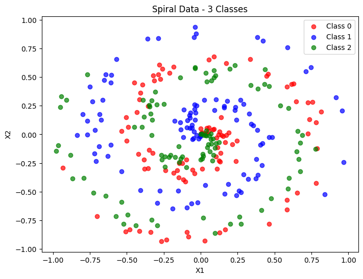

```python
import matplotlib.pyplot as plt

# Визуализация на данните
plt.figure(figsize=(8, 6))
colors = ['red', 'blue', 'green']

for class_id in range(3):
    mask = y == class_id
    plt.scatter(X[mask, 0], X[mask, 1],
                color=colors[class_id],
                label=f'Class {class_id}',
                alpha=0.7)

plt.xlabel('X1')
plt.ylabel('X2')
plt.legend()
plt.title('Spiral Data - 3 Classes')
plt.show()
```

```python
# Тестване с различни точки
test_points = np.array([
    [0.0, 0.0],     # Център
    [1.0, 0.0],     # Дясно
    [-1.0, 0.0],    # Ляво
    [0.0, 1.0],     # Горе
    [0.0, -1.0],    # Долу
])

for point in test_points:
    point_2d = np.array([point])  # (1, 2)
    pred = predict(model, point_2d)
    print(f"Point {point} → Class {pred[0]}")
```

```
Point [0. 0.] → Class 1
Point [1. 0.] → Class 0
Point [-1.  0.] → Class 2
Point [0. 1.] → Class 1
Point [ 0. -1.] → Class 0
```

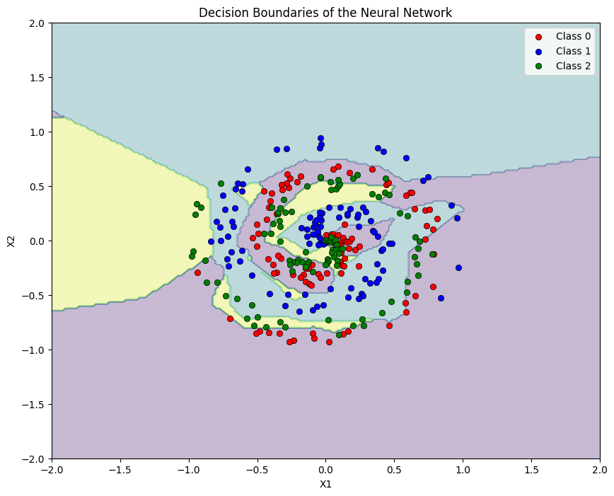

```python
# Създаване на мрежа от точки за визуализация
xx, yy = np.meshgrid(np.linspace(-2, 2, 200), np.linspace(-2, 2, 200))
grid = np.c_[xx.ravel(), yy.ravel()]

# Прогнози за всички точки в мрежата
Z = predict(model, grid)
Z = Z.reshape(xx.shape)

# Визуализация
plt.figure(figsize=(10, 8))
plt.contourf(xx, yy, Z, alpha=0.3, cmap='viridis')

# Оригинални данни
colors = ['red', 'blue', 'green']
for class_id in range(3):
    mask = y == class_id
    plt.scatter(X[mask, 0], X[mask, 1],
                color=colors[class_id],
                label=f'Class {class_id}',
                edgecolors='black', linewidth=0.5)

plt.xlabel('X1')
plt.ylabel('X2')
plt.legend()
plt.title('Decision Boundaries of the Neural Network')
plt.show()
```

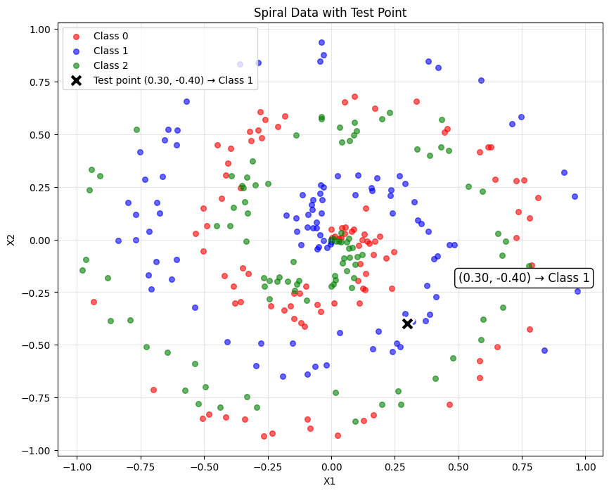

```python
from nnfs.datasets import spiral_data
import numpy as np
import nnfs
import matplotlib.pyplot as plt

nnfs.init()

# Генериране на данни
X, y = spiral_data(samples=100, classes=3)

# === ВИЗУАЛИЗАЦИЯ ===
plt.figure(figsize=(10, 8))

# Оригинални данни
colors = ['red', 'blue', 'green']
for class_id in range(3):
    mask = y == class_id
    plt.scatter(X[mask, 0], X[mask, 1],
                color=colors[class_id],
                label=f'Class {class_id}',
                alpha=0.6, s=30)

# === ИЗБЕРИ ТОЧКА ЗА ПОКАЗВАНЕ ===
point = np.array([[0.3, -0.4]])  # координати
pred = predict(model, point)     # прогноза

# Показване на точката
plt.scatter(point[0, 0], point[0, 1],
            color='black', s=200, marker='X',
            edgecolors='white', linewidth=2,
            label=f'Test point ({point[0,0]:.2f}, {point[0,1]:.2f}) → Class {pred[0]}')

# Добавяне на текст с координатите
plt.annotate(f'({point[0,0]:.2f}, {point[0,1]:.2f}) → Class {pred[0]}',
             xy=(point[0, 0], point[0, 1]),
             xytext=(point[0, 0] + 0.2, point[0, 1] + 0.2),
             fontsize=12, color='black',
             bbox=dict(facecolor='white', edgecolor='black', boxstyle='round,pad=0.3'))

plt.xlabel('X1')
plt.ylabel('X2')
plt.legend()
plt.title('Spiral Data with Test Point')
plt.grid(True, alpha=0.3)
plt.show()
```

```python
from google.colab import drive
drive.mount('/content/drive')
```

```python
!ls "/content/drive/MyDrive/Colab Notebooks/Building Neural Networks from Scratch/22/"
```

```
'Gradient Descent Neural Network.ipynb'
```

```python
!jupyter nbconvert --to html "/content/drive/MyDrive/Colab Notebooks/Building Neural Networks from Scratch/22/Gradient Descent Neural Network.ipynb"
```

```
[NbConvertApp] Converting notebook /content/drive/MyDrive/Colab Notebooks/Building Neural Networks from Scratch/22/Gradient Descent Neural Network.ipynb to html
[NbConvertApp] WARNING | Alternative text is missing on 7 image(s).
[NbConvertApp] Writing 1093447 bytes to /content/drive/MyDrive/Colab Notebooks/Building Neural Networks from Scratch/22/Gradient Descent Neural Network.html
```